# Mid Trimester

Nzambuli Daniel

2024-06-19

# The Data

```r
library(readxl)
Mid_sem_dataset = read_excel("Mid-sem dataset.xlsx")
Mid_sem_dataset
```

```
## # A tibble: 60 × 4
##    Season Month      Year No_of_tourists
##    <chr>  <chr>     <dbl>          <dbl>
##  1 Summer January    2019          19500
##  2 Summer February   2019          21000
##  3 Autumn March      2019          23000
##  4 Autumn April      2019          25000
##  5 Autumn May        2019          27000
##  6 Winter June       2019          30000
##  7 Winter July       2019          32000
##  8 Winter August     2019          31000
##  9 Spring September  2019          29000
## 10 Spring October    2019          27000
## # ℹ 50 more rows
```

# CASE SCENARIO: TOURIST ANALYSIS IN CAPETOWN

Cape Town, a scenic destination celebrated for its breathtaking landscapes and rich cultural heritage, attracts a diverse group of tourists throughout the year. Its charming old town, scenic hiking trails, vibrant local markets, and tranquil beaches offer visitors a wide array of activities. The attached hypothetical data provides insights into the number of tourists visiting Cape Town from 2019 to 2023.

## 1. Determine the seasonal variation in tourist numbers for each using the ratio-to-moving average approach from 2019 to 2023.

### Quarterly seasonal data only

```r
seasonal_data = Mid_sem_dataset[, c(1, 3, 4)]
seasonal_data
```

```
## # A tibble: 60 × 3
##    Season  Year No_of_tourists
##    <chr>  <dbl>          <dbl>
##  1 Summer  2019          19500
##  2 Summer  2019          21000
##  3 Autumn  2019          23000
##  4 Autumn  2019          25000
##  5 Autumn  2019          27000
##  6 Winter  2019          30000
##  7 Winter  2019          32000
##  8 Winter  2019          31000
##  9 Spring  2019          29000
## 10 Spring  2019          27000
## # ℹ 50 more rows
```

#### Group by seasons in each year

All the summers in 2019 2020 2022 2023 will be under the label summer …

```r
library(tidyverse)
seasonal_data = seasonal_data %>% group_by(Year, Season) %>% summarise(No_of_tourists = sum(No_of_tourists))
seasonal_data
```

```
## # A tibble: 20 × 3
## # Groups:   Year [5]
##     Year Season No_of_tourists
##    <dbl> <chr>           <dbl>
##  1  2019 Autumn          75000
##  2  2019 Spring          81000
##  3  2019 Summer          63500
##  4  2019 Winter          93000
##  5  2020 Autumn          84000
##  6  2020 Spring          87000
##  7  2020 Summer          71000
##  8  2020 Winter          99000
##  9  2021 Autumn          93000
## 10  2021 Spring          96000
## 11  2021 Summer          79500
## 12  2021 Winter         108000
## 13  2022 Autumn         108000
## 14  2022 Spring         111000
## 15  2022 Summer          95000
## 16  2022 Winter         123000
## 17  2023 Autumn         123000
## 18  2023 Spring         103000
## 19  2023 Summer         102000
## 20  2023 Winter         120000
```

#### Reorder the column of season to appear like the original

target order is `Summer, Autumn, Winter, Spring`

```r
seasonal_data$Season = factor(seasonal_data$Season, levels = c("Summer", "Autumn", "Winter", "Spring"))
seasonal_data = seasonal_data[order(seasonal_data$Year, seasonal_data$Season),]
seasonal_data
```

```
## # A tibble: 20 × 3
## # Groups:   Year [5]
##     Year Season No_of_tourists
##    <dbl> <fct>           <dbl>
##  1  2019 Summer          63500
##  2  2019 Autumn          75000
##  3  2019 Winter          93000
##  4  2019 Spring          81000
##  5  2020 Summer          71000
##  6  2020 Autumn          84000
##  7  2020 Winter          99000
##  8  2020 Spring          87000
##  9  2021 Summer          79500
## 10  2021 Autumn          93000
## 11  2021 Winter         108000
## 12  2021 Spring          96000
## 13  2022 Summer          95000
## 14  2022 Autumn         108000
## 15  2022 Winter         123000
## 16  2022 Spring         111000
## 17  2023 Summer         102000
## 18  2023 Autumn         123000
## 19  2023 Winter         120000
## 20  2023 Spring         103000
```

#### Moving average

$$MA_t = \frac{1}{no.\ seasons} \sum^{t + 3}_{i = 1} x_i\\
= \frac{1}{4}\sum^{t + 3}_{i = 1} x_i$$

```r
mov_avg = zoo::rollmean(seasonal_data$No_of_tourists, k = 4, fill = NA, align = "center")
mov_avg
```

```
##  [1]     NA  78125  80000  82250  83750  85250  87375  89625  91875  94125
## [11]  98000 101750 105500 109250 111000 114750 114000 112000     NA     NA
```

```r
seasonal_data$mov_avg = mov_avg
seasonal_data
```

```
## # A tibble: 20 × 4
## # Groups:   Year [5]
##     Year Season No_of_tourists mov_avg
##    <dbl> <fct>           <dbl>   <dbl>
##  1  2019 Summer          63500      NA
##  2  2019 Autumn          75000   78125
##  3  2019 Winter          93000   80000
##  4  2019 Spring          81000   82250
##  5  2020 Summer          71000   83750
##  6  2020 Autumn          84000   85250
##  7  2020 Winter          99000   87375
##  8  2020 Spring          87000   89625
##  9  2021 Summer          79500   91875
## 10  2021 Autumn          93000   94125
## 11  2021 Winter         108000   98000
## 12  2021 Spring          96000  101750
## 13  2022 Summer          95000  105500
## 14  2022 Autumn         108000  109250
## 15  2022 Winter         123000  111000
## 16  2022 Spring         111000  114750
## 17  2023 Summer         102000  114000
## 18  2023 Autumn         123000  112000
## 19  2023 Winter         120000      NA
## 20  2023 Spring         103000      NA
```

```r
rat_mn = zoo::rollmean(seasonal_data$mov_avg, k = 2, fill = NA, align = "center")
rat_mn = c(NA, rat_mn[1:19])
rat_mn
```

```
##  [1]       NA       NA  79062.5  81125.0  83000.0  84500.0  86312.5  88500.0
##  [9]  90750.0  93000.0  96062.5  99875.0 103625.0 107375.0 110125.0 112875.0
## [17] 114375.0 113000.0       NA       NA
```

#### Centered Moving Average

$$CMA_t = \frac{1}{2} (x_t + x_{t + 1})$$

```r
seasonal_data$rat_mn = rat_mn
seasonal_data
```

```
## # A tibble: 20 × 5
## # Groups:   Year [5]
##     Year Season No_of_tourists mov_avg  rat_mn
##    <dbl> <fct>           <dbl>   <dbl>   <dbl>
##  1  2019 Summer          63500      NA     NA
##  2  2019 Autumn          75000   78125     NA
##  3  2019 Winter          93000   80000  79062.
##  4  2019 Spring          81000   82250  81125
##  5  2020 Summer          71000   83750  83000
##  6  2020 Autumn          84000   85250  84500
##  7  2020 Winter          99000   87375  86312.
##  8  2020 Spring          87000   89625  88500
##  9  2021 Summer          79500   91875  90750
## 10  2021 Autumn          93000   94125  93000
## 11  2021 Winter         108000   98000  96062.
## 12  2021 Spring          96000  101750  99875
## 13  2022 Summer          95000  105500 103625
## 14  2022 Autumn         108000  109250 107375
## 15  2022 Winter         123000  111000 110125
## 16  2022 Spring         111000  114750 112875
## 17  2023 Summer         102000  114000 114375
## 18  2023 Autumn         123000  112000 113000
## 19  2023 Winter         120000      NA     NA
## 20  2023 Spring         103000      NA     NA
```

#### Seasonal Ratio

$$seasonal\ relatives = \frac{actual}{centralized\ avg} * 100$$

```r
seasonal_data$sn_rel = seasonal_data$No_of_tourists/ seasonal_data$rat_mn * 100
seasonal_data
```

```
## # A tibble: 20 × 6
## # Groups:   Year [5]
##     Year Season No_of_tourists mov_avg  rat_mn sn_rel
##    <dbl> <fct>           <dbl>   <dbl>   <dbl>  <dbl>
##  1  2019 Summer          63500      NA     NA    NA
##  2  2019 Autumn          75000   78125     NA    NA
##  3  2019 Winter          93000   80000  79062.  118.
##  4  2019 Spring          81000   82250  81125    99.8
##  5  2020 Summer          71000   83750  83000    85.5
##  6  2020 Autumn          84000   85250  84500    99.4
##  7  2020 Winter          99000   87375  86312.  115.
##  8  2020 Spring          87000   89625  88500    98.3
##  9  2021 Summer          79500   91875  90750    87.6
## 10  2021 Autumn          93000   94125  93000   100
## 11  2021 Winter         108000   98000  96062.  112.
## 12  2021 Spring          96000  101750  99875    96.1
## 13  2022 Summer          95000  105500 103625    91.7
## 14  2022 Autumn         108000  109250 107375   101.
## 15  2022 Winter         123000  111000 110125   112.
## 16  2022 Spring         111000  114750 112875    98.3
## 17  2023 Summer         102000  114000 114375    89.2
## 18  2023 Autumn         123000  112000 113000   109.
## 19  2023 Winter         120000      NA     NA    NA
## 20  2023 Spring         103000      NA     NA    NA
```

#### Pivot the seasonal indexes wider

```r
seas_wide = pivot_wider(seasonal_data[, c(1, 2, 6)], names_from = Year, values_from = sn_rel)
seas_wide
```

```
## # A tibble: 4 × 6
##   Season `2019` `2020` `2021` `2022` `2023`
##   <fct>   <dbl>  <dbl>  <dbl>  <dbl>  <dbl>
## 1 Summer   NA     85.5   87.6   91.7   89.2
## 2 Autumn   NA     99.4  100    101.   109.
## 3 Winter  118.   115.   112.   112.    NA
## 4 Spring   99.8   98.3   96.1   98.3   NA
```

#### find the median value

```r
seas_wide$median = apply(seas_wide[,2:6], 1, function(x) median(x, na.rm = T))
seas_wide
```

```
## # A tibble: 4 × 7
##   Season `2019` `2020` `2021` `2022` `2023` median
##   <fct>   <dbl>  <dbl>  <dbl>  <dbl>  <dbl>  <dbl>
## 1 Summer   NA     85.5   87.6   91.7   89.2   88.4
## 2 Autumn   NA     99.4  100    101.   109.   100.
## 3 Winter  118.   115.   112.   112.    NA    114.
## 4 Spring   99.8   98.3   96.1   98.3   NA     98.3
```

#### Adjusted Seasonal indexes

```r
tot_seas_median = mean(seas_wide$median)
seas_wide$seas_ind = seas_wide$median / tot_seas_median * 100
seas_wide
```

```
## # A tibble: 4 × 8
##   Season `2019` `2020` `2021` `2022` `2023` median seas_ind
##   <fct>   <dbl>  <dbl>  <dbl>  <dbl>  <dbl>  <dbl>    <dbl>
## 1 Summer   NA     85.5   87.6   91.7   89.2   88.4     88.3
## 2 Autumn   NA     99.4  100    101.   109.   100.     100.
## 3 Winter  118.   115.   112.   112.    NA    114.     113.
## 4 Spring   99.8   98.3   96.1   98.3   NA     98.3     98.2
```

### Monthly seasonal data

#### Combine the initial code to a function

```r
present_month = function(data, x, season_size){
  mov_avg = zoo::rollmean(data[[x]], k = season_size, fill = NA, align = "center")
  print("The moving average is:")
  print(mov_avg)
  rat_mn = zoo::rollmean(mov_avg, k = 2, fill = NA, align = "center")
  rat_mn = c(NA, rat_mn[1:(length(rat_mn) -1)])
  print("The centralized moving average is:")
  print(rat_mn)
  sn_rel = month_data$No_of_tourists/ rat_mn * 100
  print("The seasonal relative is:")
  print(sn_rel)
  long = data.frame(Year = data[,2],
                    Season = data[, 1],
                    sn_rel = sn_rel)
  wide = pivot_wider(long, names_from = Year, values_from = sn_rel)
  print("The data in wide format is:")
  print(wide)
  wide$median = apply(wide[,2:ncol(wide)], 1, function(x) median(x, na.rm = T))
  tot_seas_median = mean(wide$median)
  wide$seas_ind = wide$median / tot_seas_median * 100
  print("With seasonal index")
  return(wide)
}
```

#### The annual data

```r
month_data = Mid_sem_dataset[, c(2, 3, 4)]
colnames(month_data)
```

```
## [1] "Month"          "Year"           "No_of_tourists"
```

```r
month_wide = present_month(month_data,"No_of_tourists", 12)
```

```
## [1] "The moving average is:"
##  [1]       NA       NA       NA       NA       NA 26041.67 26250.00 26500.00
##  [9] 26750.00 27000.00 27250.00 27416.67 27583.33 27750.00 27916.67 28083.33
## [17] 28250.00 28416.67 28625.00 28875.00 29125.00 29375.00 29625.00 29875.00
## [25] 30125.00 30375.00 30625.00 30875.00 31125.00 31375.00 31833.33 32250.00
## [33] 32666.67 33083.33 33500.00 33916.67 34333.33 34750.00 35166.67 35583.33
## [41] 36000.00 36416.67 36833.33 37250.00 37666.67 38083.33 38500.00 38333.33
## [49] 38333.33 38250.00 38083.33 37833.33 37583.33 37333.33       NA       NA
## [57]       NA       NA       NA       NA
## [1] "The centralized moving average is:"
##  [1]       NA       NA       NA       NA       NA       NA 26145.83 26375.00
##  [9] 26625.00 26875.00 27125.00 27333.33 27500.00 27666.67 27833.33 28000.00
## [17] 28166.67 28333.33 28520.83 28750.00 29000.00 29250.00 29500.00 29750.00
## [25] 30000.00 30250.00 30500.00 30750.00 31000.00 31250.00 31604.17 32041.67
## [33] 32458.33 32875.00 33291.67 33708.33 34125.00 34541.67 34958.33 35375.00
```

[output cut: 30 more lines]

```r
month_wide
```

```
## # A tibble: 12 × 8
##    Month     `2019` `2020` `2021` `2022` `2023` median seas_ind
##    <chr>      <dbl>  <dbl>  <dbl>  <dbl>  <dbl>  <dbl>    <dbl>
##  1 January     NA     80     81.7   87.9   91.3   84.8     84.6
##  2 February    NA     86.7   89.3   92.6   96.6   90.9     90.8
##  3 March       NA     93.4   95.1   97.3  102.    96.2     96.0
##  4 April       NA    100    101.   102.   108.   101.     101.
##  5 May         NA    107.   106.   106.   114.   106.     106.
##  6 June        NA    113.   112    110.   101.   111.     111.
##  7 July       122.   119.   117.   115.    NA    118.     118.
##  8 August     118.   115.   112.   111.    NA    114.     113.
##  9 September  109.   107.   105.   104.    NA    106.     106.
## 10 October    100.    99.1   97.3   97.7   NA     98.4     98.2
## 11 November    92.2   91.5   90.1   91.4   NA     91.5     91.3
## 12 December    84.1   84.0   83.1   85.9   NA     84.1     83.9
```

## 2. Obtain a clearer view of the underlying trend by eliminating seasonal fluctuations.

### Monthly Data

```r
monthly_smoothed_data = data.frame(month = rep(month_wide$Month, 5),
                               year = rep(seq(2019, 2023), 12),
                               tourists = month_data$No_of_tourists,
                               adj_seas_ind = rep(month_wide$seas_ind, 5))

monthly_smoothed_data$deseason = monthly_smoothed_data$tourists/ monthly_smoothed_data$adj_seas_ind * 100
monthly_smoothed_data
```

```
##        month year tourists adj_seas_ind deseason
## 1    January 2019    19500     84.61872 23044.55
## 2   February 2020    21000     90.76591 23136.44
## 3      March 2021    23000     95.97674 23964.14
## 4      April 2022    25000    101.08602 24731.41
## 5        May 2023    27000    106.26593 25407.96
## 6       June 2019    30000    111.01201 27024.10
## 7       July 2020    32000    117.90435 27140.65
## 8     August 2021    31000    113.33957 27351.44
## 9  September 2022    29000    105.61012 27459.49
## 10   October 2023    27000     98.21944 27489.47
## 11  November 2019    25000     91.28047 27388.12
## 12  December 2020    23000     83.92073 27406.82
## 13   January 2021    22000     84.61872 25998.98
## 14  February 2022    24000     90.76591 26441.65
```

[output cut: 46 more lines]

### Quarterly data

```r
quarter_smoothed_data = data.frame(quarter = rep(seas_wide$Season, 5),
                               year = rep(seq(2019, 2023), 4),
                               adj_seas_ind = rep(seas_wide$seas_ind, 5))
quarter_smoothed_data = quarter_smoothed_data[order(quarter_smoothed_data$year),]
quarter_smoothed_data$tourist = seasonal_data$No_of_tourists


quarter_smoothed_data$deseasoned = quarter_smoothed_data$tourist/quarter_smoothed_data$adj_seas_ind * 100

rownames(quarter_smoothed_data) = NULL
quarter_smoothed_data
```

```
##    quarter year adj_seas_ind tourist deseasoned
## 1   Summer 2019     88.26648   63500   71941.24
## 2   Autumn 2019    100.14883   75000   74888.54
## 3   Winter 2019    113.40212   93000   82009.05
## 4   Spring 2019     98.18256   81000   82499.37
## 5   Autumn 2020    100.14883   71000   70894.49
## 6   Winter 2020    113.40212   84000   74072.69
## 7   Spring 2020     98.18256   99000  100832.57
## 8   Summer 2020     88.26648   87000   98565.16
## 9   Winter 2021    113.40212   79500   70104.51
## 10  Spring 2021     98.18256   93000   94721.50
## 11  Summer 2021     88.26648  108000  122356.75
## 12  Autumn 2021    100.14883   96000   95857.34
## 13  Spring 2022     98.18256   95000   96758.52
## 14  Summer 2022     88.26648  108000  122356.75
## 15  Autumn 2022    100.14883  123000  122817.21
## 16  Winter 2022    113.40212  111000   97881.76
## 17  Summer 2023     88.26648  102000  115559.15
## 18  Autumn 2023    100.14883  123000  122817.21
## 19  Winter 2023    113.40212  120000  105818.12
## 20  Spring 2023     98.18256  103000  104906.61
```

## 3. Compute the long-term trend in tourist numbers over the specified period by applying the suitable trend analysis to the deseasonalized data.

if a linear model is to be used

$$trend\ line = \beta_0 + \beta_1 t$$

otherwise for quadratic

$$trend\ line = \beta_0 + \beta_1 t + \beta_2t^2$$

and for exponential

$$trend\ line = \beta_0 + e^{\beta_1 t}$$

### Generate t

```r
nrow(monthly_smoothed_data)
```

```
## [1] 60
```

60 is even so

$$x_t = 2(t - median(t))$$

### Month data

```r
monthly_smoothed_data$t = seq(1:nrow(monthly_smoothed_data))
med_month_t = median(monthly_smoothed_data$t)
monthly_smoothed_data$x_t = 2*(monthly_smoothed_data$t - med_month_t)
monthly_smoothed_data$t_sqrd = monthly_smoothed_data$t^2
monthly_smoothed_data
```

```
##        month year tourists adj_seas_ind deseason  t x_t t_sqrd
## 1    January 2019    19500     84.61872 23044.55  1 -59      1
## 2   February 2020    21000     90.76591 23136.44  2 -57      4
## 3      March 2021    23000     95.97674 23964.14  3 -55      9
## 4      April 2022    25000    101.08602 24731.41  4 -53     16
## 5        May 2023    27000    106.26593 25407.96  5 -51     25
## 6       June 2019    30000    111.01201 27024.10  6 -49     36
## 7       July 2020    32000    117.90435 27140.65  7 -47     49
## 8     August 2021    31000    113.33957 27351.44  8 -45     64
## 9  September 2022    29000    105.61012 27459.49  9 -43     81
## 10   October 2023    27000     98.21944 27489.47 10 -41    100
## 11  November 2019    25000     91.28047 27388.12 11 -39    121
## 12  December 2020    23000     83.92073 27406.82 12 -37    144
## 13   January 2021    22000     84.61872 25998.98 13 -35    169
## 14  February 2022    24000     90.76591 26441.65 14 -33    196
```

[output cut: 46 more lines]

After the transformation, the normal equations for linear trend line are:

$$\sum Y_t = n\beta_0 + \beta_1\sum X_t$$

```r
sum(monthly_smoothed_data$x_t)
```

```
## [1] 0
```

therefore

$$\frac{\sum Y_t}{n} = \beta_0$$

additionally

$$\sum X_t Y_t = \beta_0 \sum X_t + \beta_1 \sum X_t^2\\
= \beta_1 \sum X_t^2$$

add the column for $X_t Y_t$ and $X_t^2$

```r
monthly_smoothed_data$XY = monthly_smoothed_data$deseason * monthly_smoothed_data$x_t
monthly_smoothed_data$x_sqrd = monthly_smoothed_data$x_t^2
monthly_smoothed_data
```

```
##        month year tourists adj_seas_ind deseason  t x_t t_sqrd          XY
## 1    January 2019    19500     84.61872 23044.55  1 -59      1 -1359628.27
## 2   February 2020    21000     90.76591 23136.44  2 -57      4 -1318777.06
## 3      March 2021    23000     95.97674 23964.14  3 -55      9 -1318027.72
## 4      April 2022    25000    101.08602 24731.41  4 -53     16 -1310764.77
## 5        May 2023    27000    106.26593 25407.96  5 -51     25 -1295805.77
## 6       June 2019    30000    111.01201 27024.10  6 -49     36 -1324181.02
## 7       July 2020    32000    117.90435 27140.65  7 -47     49 -1275610.32
## 8     August 2021    31000    113.33957 27351.44  8 -45     64 -1230814.59
## 9  September 2022    29000    105.61012 27459.49  9 -43     81 -1180758.06
## 10   October 2023    27000     98.21944 27489.47 10 -41    100 -1127068.08
## 11  November 2019    25000     91.28047 27388.12 11 -39    121 -1068136.53
## 12  December 2020    23000     83.92073 27406.82 12 -37    144 -1014052.25
## 13   January 2021    22000     84.61872 25998.98 13 -35    169  -909964.16
## 14  February 2022    24000     90.76591 26441.65 14 -33    196  -872574.30
```

[output cut: 107 more lines]

### Trend Values

#### 1. simple linear

```r
summary(lm(deseason~x_t, data = monthly_smoothed_data))
```

```
##
## Call:
## lm(formula = deseason ~ x_t, data = monthly_smoothed_data)
##
## Residuals:
##     Min      1Q  Median      3Q     Max
## -4316.3  -831.0  -178.6  1186.0  4723.7
##
## Coefficients:
##              Estimate Std. Error t value Pr(>|t|)
## (Intercept) 31922.204    247.892  128.78   <2e-16 ***
## x_t           127.463      7.157   17.81   <2e-16 ***
## ---
## Signif. codes:  0 '***' 0.001 '**' 0.01 '*' 0.05 '.' 0.1 ' ' 1
##
## Residual standard error: 1920 on 58 degrees of freedom
## Multiple R-squared:  0.8454, Adjusted R-squared:  0.8427
## F-statistic: 317.2 on 1 and 58 DF,  p-value: < 2.2e-16
```

#### 2. quadratic trend

```r
summary(lm(deseason~poly(x_t, 2, raw = T), data = monthly_smoothed_data))
```

```
##
## Call:
## lm(formula = deseason ~ poly(x_t, 2, raw = T), data = monthly_smoothed_data)
##
## Residuals:
##     Min      1Q  Median      3Q     Max
## -3347.7 -1131.4  -466.2   940.3  4813.5
##
## Coefficients:
##                          Estimate Std. Error t value Pr(>|t|)
## (Intercept)            32558.7662   357.7195  91.018   <2e-16 ***
## poly(x_t, 2, raw = T)1   127.4627     6.8837  18.517   <2e-16 ***
## poly(x_t, 2, raw = T)2    -0.5306     0.2223  -2.387   0.0203 *
## ---
## Signif. codes:  0 '***' 0.001 '**' 0.01 '*' 0.05 '.' 0.1 ' ' 1
##
## Residual standard error: 1847 on 57 degrees of freedom
## Multiple R-squared:  0.8595, Adjusted R-squared:  0.8545
## F-statistic: 174.3 on 2 and 57 DF,  p-value: < 2.2e-16
```

```r
summary(lm(deseason~x_t + x_sqrd, data = monthly_smoothed_data))
```

```
##
## Call:
## lm(formula = deseason ~ x_t + x_sqrd, data = monthly_smoothed_data)
##
## Residuals:
##     Min      1Q  Median      3Q     Max
## -3347.7 -1131.4  -466.2   940.3  4813.5
##
## Coefficients:
##               Estimate Std. Error t value Pr(>|t|)
## (Intercept) 32558.7662   357.7195  91.018   <2e-16 ***
## x_t           127.4627     6.8837  18.517   <2e-16 ***
## x_sqrd         -0.5306     0.2223  -2.387   0.0203 *
## ---
## Signif. codes:  0 '***' 0.001 '**' 0.01 '*' 0.05 '.' 0.1 ' ' 1
##
## Residual standard error: 1847 on 57 degrees of freedom
## Multiple R-squared:  0.8595, Adjusted R-squared:  0.8545
## F-statistic: 174.3 on 2 and 57 DF,  p-value: < 2.2e-16
```

#### 3. exponential

```r
summary(nls(deseason~a + exp(b * x_t), data = monthly_smoothed_data, start = list(a = 1, b = 0.1)))
```

```
##
## Formula: deseason ~ a + exp(b * x_t)
##
## Parameters:
##    Estimate Std. Error t value Pr(>|t|)
## a 3.148e+04  6.368e+02   49.44   <2e-16 ***
## b 1.497e-01  8.509e-03   17.60   <2e-16 ***
## ---
## Signif. codes:  0 '***' 0.001 '**' 0.01 '*' 0.05 '.' 0.1 ' ' 1
##
## Residual standard error: 4681 on 58 degrees of freedom
##
## Number of iterations to convergence: 8
## Achieved convergence tolerance: 3.996e-06
```

#### compare the models

Lower **Residual R** values indicate a better fit.

```r
quadratic_model = lm(deseason~poly(x_t, 2, raw = T), data = monthly_smoothed_data)
linear_model = lm(deseason~x_t, data = monthly_smoothed_data)

linear_residual_R = summary(linear_model)$sigma
quadrat_residual_R = summary(quadratic_model)$sigma
if (linear_residual_R < quadrat_residual_R){
  print("Linear Model is the best model")
}else if(linear_residual_R == quadrat_residual_R){
  print("any model can be used")
}else{
  print("Quadratic Model is the best model")
}
```

```
## [1] "Quadratic Model is the best model"
```

#### quad vs exp

```r
exp_model = nls(deseason~a + exp(b * x_t), data = monthly_smoothed_data, start = list(a = 1, b = 0.1))

exp_residual_R = summary(exp_model)$sigma
if (exp_residual_R < quadrat_residual_R){
  print("Exponential Model is the best model")
}else if(linear_residual_R == quadrat_residual_R){
  print("any model can be used; Exponential or Quadratic")
}else{
  print("Quadratic Model is the best model")
}
```

```
## [1] "Quadratic Model is the best model"
```

#### Choosing quadratic model

```r
coeff_monthly = coef(quadratic_model)
coeff_monthly
```

```
##            (Intercept) poly(x_t, 2, raw = T)1 poly(x_t, 2, raw = T)2
##          32558.7662374            127.4626974             -0.5306161
```

```r
monthly_b0 = coeff_monthly[1]
monthly_b1 = coeff_monthly[2]
monthly_b2 = coeff_monthly[3]
```

```r
monthly_smoothed_data$trend = monthly_b0 + (monthly_b1 * monthly_smoothed_data$t) + (monthly_b2 * monthly_smoothed_data$t_sqrd)
monthly_smoothed_data
```

```
##        month year tourists adj_seas_ind deseason  t x_t t_sqrd          XY
## 1    January 2019    19500     84.61872 23044.55  1 -59      1 -1359628.27
## 2   February 2020    21000     90.76591 23136.44  2 -57      4 -1318777.06
## 3      March 2021    23000     95.97674 23964.14  3 -55      9 -1318027.72
## 4      April 2022    25000    101.08602 24731.41  4 -53     16 -1310764.77
## 5        May 2023    27000    106.26593 25407.96  5 -51     25 -1295805.77
## 6       June 2019    30000    111.01201 27024.10  6 -49     36 -1324181.02
## 7       July 2020    32000    117.90435 27140.65  7 -47     49 -1275610.32
## 8     August 2021    31000    113.33957 27351.44  8 -45     64 -1230814.59
## 9  September 2022    29000    105.61012 27459.49  9 -43     81 -1180758.06
## 10   October 2023    27000     98.21944 27489.47 10 -41    100 -1127068.08
## 11  November 2019    25000     91.28047 27388.12 11 -39    121 -1068136.53
## 12  December 2020    23000     83.92073 27406.82 12 -37    144 -1014052.25
## 13   January 2021    22000     84.61872 25998.98 13 -35    169  -909964.16
## 14  February 2022    24000     90.76591 26441.65 14 -33    196  -872574.30
```

[output cut: 107 more lines]

### quarter

```r
nrow(quarter_smoothed_data)
```

```
## [1] 20
```

```r
quarter_smoothed_data$t = seq(1, 20)
med_quarter = median(quarter_smoothed_data$t)
quarter_smoothed_data$x = 2 * (quarter_smoothed_data$t- med_quarter)
```

#### Compare the models

```r
quadratic_model_q = lm(deseasoned~poly(x, 2, raw = T), data = quarter_smoothed_data)
linear_model_q = lm(deseasoned~x, data = quarter_smoothed_data)

linear_residual_R = summary(linear_model_q)$sigma
quadrat_residual_R = summary(quadratic_model_q)$sigma
if (linear_residual_R < quadrat_residual_R){
  print("Linear Model is the best model")
}else if(linear_residual_R == quadrat_residual_R){
  print("any model can be used")
}else{
  print("Quadratic Model is the best model")
}
```

```
## [1] "Quadratic Model is the best model"
```

```r
quarter_smoothed_data$log_deseason = log(quarter_smoothed_data$deseasoned)
exp_model_q = lm(log_deseason~x, data = quarter_smoothed_data)

exp_residual_R = summary(exp_model_q)$sigma
if (exp_residual_R < quadrat_residual_R){
  print("Exponential Model is the best model")
}else if(linear_residual_R == quadrat_residual_R){
  print("any model can be used; Exponential or Quadratic")
}else{
  print("Quadratic Model is the best model")
}
```

```
## [1] "Exponential Model is the best model"
```

#### Generate the rest of the columns

```r
quarter_smoothed_data$XY = quarter_smoothed_data$deseasoned * quarter_smoothed_data$x
quarter_smoothed_data$x_sqrd = quarter_smoothed_data$x^2
quarter_smoothed_data$t_sqrd = quarter_smoothed_data$t^2
quarter_coeff = coef(exp_model_q)
quarter_coeff
```

```
## (Intercept)           x
## 11.45783071  0.01279659
```

```r
quarter_b0 = exp(quarter_coeff[1])
quarter_b0
```

```
## (Intercept)
##    94639.55
```

```r
quarter_b1 = quarter_coeff[2]
quarter_b1
```

```
##          x
## 0.01279659
```

```r
quarter_smoothed_data$trend = quarter_b0 + exp(quarter_b1 * quarter_smoothed_data$t)
quarter_smoothed_data
```

```
##    quarter year adj_seas_ind tourist deseasoned  t   x log_deseason         XY
## 1   Summer 2019     88.26648   63500   71941.24  1 -19     11.18360 -1366883.5
## 2   Autumn 2019    100.14883   75000   74888.54  2 -17     11.22376 -1273105.2
## 3   Winter 2019    113.40212   93000   82009.05  3 -15     11.31458 -1230135.7
## 4   Spring 2019     98.18256   81000   82499.37  4 -13     11.32055 -1072491.9
## 5   Autumn 2020    100.14883   71000   70894.49  5 -11     11.16895  -779839.4
## 6   Winter 2020    113.40212   84000   74072.69  6  -9     11.21280  -666654.2
## 7   Spring 2020     98.18256   99000  100832.57  7  -7     11.52122  -705828.0
## 8   Summer 2020     88.26648   87000   98565.16  8  -5     11.49847  -492825.8
## 9   Winter 2021    113.40212   79500   70104.51  9  -3     11.15774  -210313.5
## 10  Spring 2021     98.18256   93000   94721.50 10  -1     11.45870   -94721.5
## 11  Summer 2021     88.26648  108000  122356.75 11   1     11.71470   122356.8
## 12  Autumn 2021    100.14883   96000   95857.34 12   3     11.47062   287572.0
## 13  Spring 2022     98.18256   95000   96758.52 13   5     11.47997   483792.6
## 14  Summer 2022     88.26648  108000  122356.75 14   7     11.71470   856497.3
```

[output cut: 27 more lines]

## 4. Obtain the cyclic index to better understand the cyclical variations in tourist numbers that may be influenced by economic cycles or other factors.

$$cyclic\ index = \frac{deseasonalized\ data}{trend\ value} * 100$$

### Monthly

```r
monthly_smoothed_data$cyclic = monthly_smoothed_data$deseason/ monthly_smoothed_data$trend * 100
monthly_smoothed_data
```

```
##        month year tourists adj_seas_ind deseason  t x_t t_sqrd          XY
## 1    January 2019    19500     84.61872 23044.55  1 -59      1 -1359628.27
## 2   February 2020    21000     90.76591 23136.44  2 -57      4 -1318777.06
## 3      March 2021    23000     95.97674 23964.14  3 -55      9 -1318027.72
## 4      April 2022    25000    101.08602 24731.41  4 -53     16 -1310764.77
## 5        May 2023    27000    106.26593 25407.96  5 -51     25 -1295805.77
## 6       June 2019    30000    111.01201 27024.10  6 -49     36 -1324181.02
## 7       July 2020    32000    117.90435 27140.65  7 -47     49 -1275610.32
## 8     August 2021    31000    113.33957 27351.44  8 -45     64 -1230814.59
## 9  September 2022    29000    105.61012 27459.49  9 -43     81 -1180758.06
## 10   October 2023    27000     98.21944 27489.47 10 -41    100 -1127068.08
## 11  November 2019    25000     91.28047 27388.12 11 -39    121 -1068136.53
## 12  December 2020    23000     83.92073 27406.82 12 -37    144 -1014052.25
## 13   January 2021    22000     84.61872 25998.98 13 -35    169  -909964.16
## 14  February 2022    24000     90.76591 26441.65 14 -33    196  -872574.30
```

[output cut: 107 more lines]

### Quarters

```r
quarter_smoothed_data$cyclic = quarter_smoothed_data$deseason/ quarter_smoothed_data$trend * 100
quarter_smoothed_data
```

```
##    quarter year adj_seas_ind tourist deseasoned  t   x log_deseason         XY
## 1   Summer 2019     88.26648   63500   71941.24  1 -19     11.18360 -1366883.5
## 2   Autumn 2019    100.14883   75000   74888.54  2 -17     11.22376 -1273105.2
## 3   Winter 2019    113.40212   93000   82009.05  3 -15     11.31458 -1230135.7
## 4   Spring 2019     98.18256   81000   82499.37  4 -13     11.32055 -1072491.9
## 5   Autumn 2020    100.14883   71000   70894.49  5 -11     11.16895  -779839.4
## 6   Winter 2020    113.40212   84000   74072.69  6  -9     11.21280  -666654.2
## 7   Spring 2020     98.18256   99000  100832.57  7  -7     11.52122  -705828.0
## 8   Summer 2020     88.26648   87000   98565.16  8  -5     11.49847  -492825.8
## 9   Winter 2021    113.40212   79500   70104.51  9  -3     11.15774  -210313.5
## 10  Spring 2021     98.18256   93000   94721.50 10  -1     11.45870   -94721.5
## 11  Summer 2021     88.26648  108000  122356.75 11   1     11.71470   122356.8
## 12  Autumn 2021    100.14883   96000   95857.34 12   3     11.47062   287572.0
## 13  Spring 2022     98.18256   95000   96758.52 13   5     11.47997   483792.6
## 14  Summer 2022     88.26648  108000  122356.75 14   7     11.71470   856497.3
```

[output cut: 27 more lines]

## 5. Generate graphs of the data to illustrate the seasonal, trend, and cyclic components in the number of tourists visiting Cape Town.

### Monthly

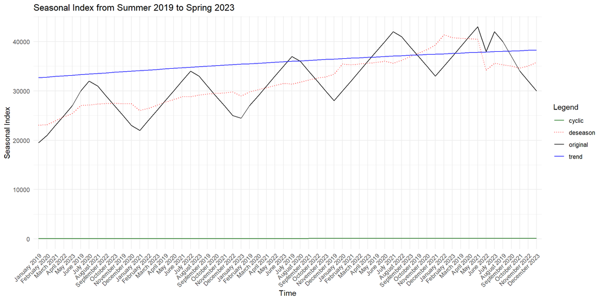

```r
months = c(
  "January", "February", "March", "April", "May", "June",
  "July", "August", "September", "October", "November", "December"
)

monthly_smoothed_data$month = factor(monthly_smoothed_data$month, levels = months)
monthly_smoothed_data$season_year = paste(monthly_smoothed_data$month, monthly_smoothed_data$year)
monthly_smoothed_data$season_year = factor(monthly_smoothed_data$season_year, levels = unique(monthly_smoothed_data$season_year))
#
#
ggplot(monthly_smoothed_data, aes(x = season_year)) +
  geom_line(aes(y = tourists, color = "original"), group = 1) +
  # geom_line(aes(y = adj_seas_ind, color = "seasonal"), group = 1) +
  geom_line(aes(y = deseason, color = "deseason"), group = 1, linetype = "dotted") +
  geom_line(aes(y = trend, color = "trend"), group = 1) +
  geom_line(aes(y = cyclic, color = "cyclic"), group = 1) +
  labs(title = "Seasonal Index from Summer 2019 to Spring 2023",
       x = "Time",
       y = "Seasonal Index") +
  theme_minimal() +
  scale_color_manual(name = "Legend", values = c("original" = "black", "trend"= "blue", "cyclic" = "darkgreen", "deseason" = "red"))+
  theme(axis.text.x = element_text(angle = 45, hjust = 1))
```

### Quarter

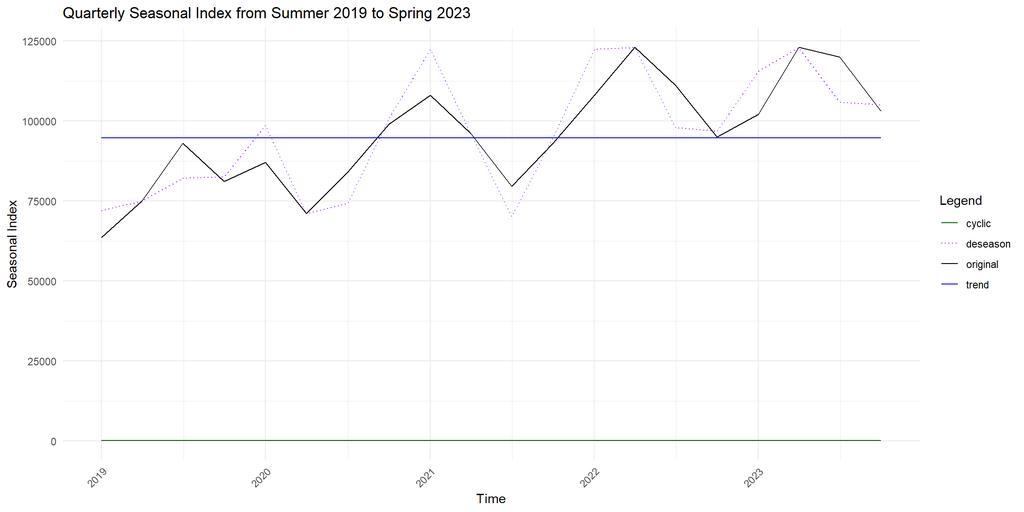

```r
quarter_smoothed_data$date = as.Date(paste(quarter_smoothed_data$year, as.numeric(quarter_smoothed_data$quarter) * 3 - 2, "1", sep = "-"), format = "%Y-%m-%d")

quarter_smoothed_data$season_year = paste(quarter_smoothed_data$quarter, quarter_smoothed_data$year)

ggplot(quarter_smoothed_data, aes(x = date)) +
  geom_line(aes(y = tourist, color = "original"), group = 1) +
  geom_line(aes(y = deseasoned, color = "deseason"), group = 1, linetype = "dotted") +
  geom_line(aes(y = trend, color = "trend"), group = 1) +
  geom_line(aes(y = cyclic, color = "cyclic"), group = 1) +
  labs(title = "Quarterly Seasonal Index from Summer 2019 to Spring 2023",
       x = "Time",
       y = "Seasonal Index") +
  theme_minimal() +
  scale_color_manual(name = "Legend", values = c("original" = "black", "trend"= "blue", "cyclic" = "darkgreen", "deseason" = "purple"))+
  theme(axis.text.x = element_text(angle = 45, hjust = 1))
```